# Introduction to ggplot2

Exercises

Johan Larsson

Behnaz Pirzamanbein

Jonas Wallin

# 1 ggplot2

ggplot2 is part of the **tidyverse** so you can simply call

```r
library(tidyverse)
```

to load ggplot2.

# 2 `ggplot()`

The main function of ggplot is the `ggplot()` function. It has two main arguments that you need to be aware of:

1. `data`: the (default) dataset to use for the plot
2. `mapping`: the aesthetic mappings

When calling `ggplot()` we typically don’t call these arguments by their name and instead simply supply them in order.

## 2.1 `data`

The `data` argument obviously needs a dataset and this should usually come in the form of a `data.frame` or a `tibble`. Let’s starts with a very simple data set, `mtcars`, that contains a few variables related to fuel consumption of cars.

Before doing anything else, always take a little time to look at a bit of the data. If the dataset has relatively few variables (less than ten), the `head()` function is usually your best option; it simply displays the first few rows of the data.

```r
head(mtcars)
```

```
##                    mpg cyl disp  hp drat    wt  qsec vs am gear carb
## Mazda RX4         21.0   6  160 110 3.90 2.620 16.46  0  1    4    4
## Mazda RX4 Wag     21.0   6  160 110 3.90 2.875 17.02  0  1    4    4
## Datsun 710        22.8   4  108  93 3.85 2.320 18.61  1  1    4    1
## Hornet 4 Drive    21.4   6  258 110 3.08 3.215 19.44  1  0    3    1
## Hornet Sportabout 18.7   8  360 175 3.15 3.440 17.02  0  0    3    2
## Valiant           18.1   6  225 105 2.76 3.460 20.22  1  0    3    1
```

The second argument of `head()` decides how many rows to show. Modify this value to show the first 10 cars of the dataset.

`glimpse()` is very useful when you have more variables (since it is more compact). Call `glimpse()` on `mtcars` and notice that it lists the variables in a table along with the first values of each variable.

## 2.2 `mapping`

The `mapping` argument should be supplied with a call to the `aes()` function that lists the mappings between variables in your data and aesthetics of the plot. Which aesthetics you choose to map to depends on what geoms you intend to use. But for now, let’s assume that we want to map engine displacement (`disp`) to the x axis, and fuel consumption (`mpg`) to the y axis. To do so, we simply use `aes(x = disp, y = mpg)` as the input to the `mapping` argument. Because the first two arguments of `aes()` are `x` and `y`, we can do without calling them explicitly.

Let’s put this together:

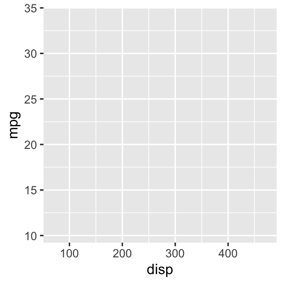

```r
ggplot(data = mtcars, aes(x = disp,y = mpg))
```

Why does this result in a blank canvas? After all, we did tell ggplot to map engine displacement to the x axis and fuel consumption to the y axis.

The answer is that we still haven’t told ggplot2 which layers we want to use.

# 3 Layers

The aesthetic mapping is not enough by itself—we also need a layer to display our data. In **ggplot2**, we accomplish this by adding (stacking) layers to the output of `ggplot()`. There are several ways to construct layers in ggplot, but the simplest and most common approach is to use the functions named `geom_*()` (such as `geom_point()`). You can think of these functions as a short cut to generating layers. Specify the geom you want and ggplot2 uses its predefined defaults to provide the other components of the layer.

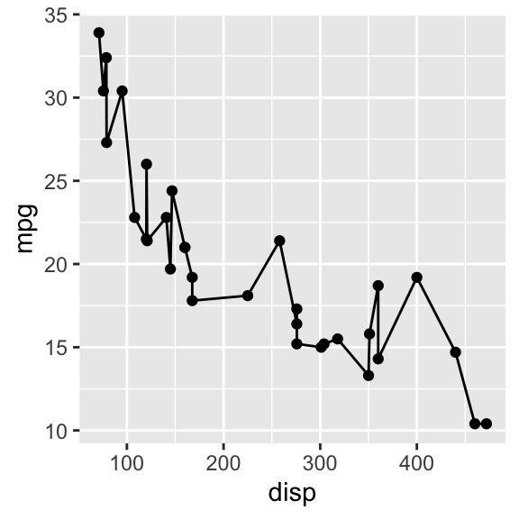

```r
ggplot(mtcars, aes(disp, mpg)) +
  geom_point() + geom_line()
```

So, in fact, `geom_point()` doesn’t just return a point geom. Instead it returns a complete layer, including a point geom.

Notice the use of `+` here to add layers to the canvas that we started out with. Also observe that we didn’t need to specify what data to use or which mappings we wanted in the call to `geom_point()`—they were inherited from the `ggplot()` call. We will return to choosing data and mappings for individual layers later in this example.

Now try to switch geom for your plot, for instance by replacing `geom_point()` with `geom_line()`.

Now let’s try using `geom_rect()` instead.

```r
ggplot(mtcars, aes(x=disp,y= mpg, width=10, height=1)) +
  geom_rect()
```

Well that didn’t work, but why not?

Well, the reason is simply that `geom_rect()` uses the rectangle geom and a rectangle needs more aesthetics than just x and y coordinates.

# 4 Aesthetics

Look at the documentation of the `geom_point()` function. Under **Aesthetics** we can see that this layer understands the following aesthetics:

- **x**
- **y**
- alpha
- colour
- fill
- group
- shape
- size
- stroke

The bold face of the first two aesthetics signify that they must be provided. The remaining aesthetics have been supplied defaults, such as `alpha = 1` (no transparency) and `colour = "black"` (black points). But these aesthetics can also be changed, either by mapping them to another variable in our data or by manually adjusting them directly.

When you change an aesthetic by specifying a value (and not a mapping) you simply specify that aesthetic in the call to the geom you would like to change. Let’s change the color of the points to navy blue, increase the size, and change shape. Doing so is a breeze with ggplot2:

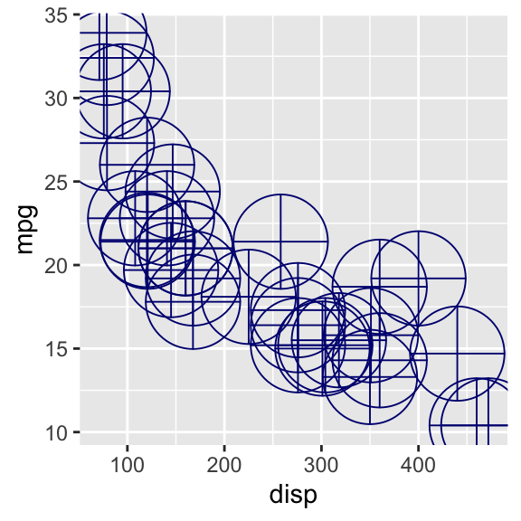

```r
ggplot(mtcars, aes(disp, mpg)) +
  geom_point(
    colour = "navy",
    size   = 18,
    shape  = 10
  )
```

Take some time to play around with the various aesthetics. Switch geom and try to flip the axes. Can you figure out what the `stroke` aesthetic does?

It might be worth noting that some of the aesthetics used here have synonyms that you will likely come across every now and then, for instance `cex = size` (for points), `col = color = colour`, `pch= shape` (for points), and `lty= linetype` (for lines) which are there mostly for reasons that are historical or have to do with compatibility.

**Note**: For more details about various formats, check the `vignette("ggplot2-specs")`.

# 5 Other Ways to Generate Layers

So far we’ve learned that the most common way to generate layers is to use `geom_*()` functions, but there are alternatives. In particular, you can also generate layers from `stat_*()` functions. Recall that the `geom_*()` functions generate layers through geom specifications. `stat_*()` functions generate layers through statistical transformations, providing defaults for the other features of a layers, such as the geom.

The `stat_identity()` function, for instance, specifies the “identity” transformation, which is really just a function that does no transformation: it simply returns its input as output. A natural default geom for the identity transformation is a point geom, so if we use `stat_identity()` like so:

```r
ggplot(mtcars, aes(disp, mpg)) +
  stat_identity()
```

We get the same scatter plot as before.

The example above is not really of much practical use. But `stat_*()` functions occasionally do come in handy. They are, for instance, natural to consider when your goal from the outset is to visualize the result of a statistical transformation (other than the identity function), such as medians of some distribution, for instance. In this example, we’ve used the `stat_summary()` function to compute medians of engine displacement across all unique values of numbers of cylinders.

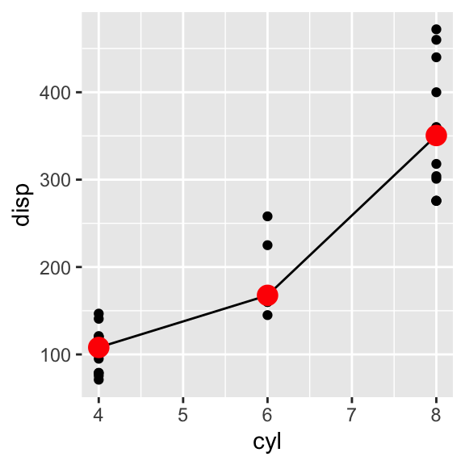

```r
ggplot(mtcars, aes(x=cyl,y= disp)) +
  geom_point() +
  stat_summary(fun = median, geom = c("line")) +
  stat_summary(fun = median, geom = "point",size=4,col='red')
```

# 6 Limits

It is sometimes handy to be able to change the limits of the visualization, in particular the limits for the x and y axes. The `coord_cartesian()` function lets us change the displayed range without removing observations from the calculations. Here, we’ve taken the previous plot and set the y-axis limits to 0 and 300.

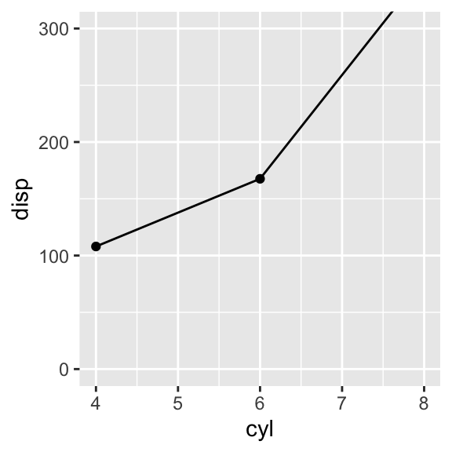

```r
ggplot(mtcars, aes(cyl, disp)) +
  stat_summary(fun = median, geom = "line") +
  stat_summary(fun = median, geom = "point") +
  coord_cartesian(ylim = c(0, 300))
```

**Note:** With `coord_cartesian(ylim = c(0, 300))`, all data will be used. For instance`stat_summary()` still uses all observations to calculate the medians. The medians are unchanged, but parts of the plot outside the displayed range are clipped. In contrast, adding `ylim(0, 300)` changes the scale limits and removes observations with displacement above 300 *before* the medians are calculated, so the medians themselves can change. The same distinction applies to `xlim()` and `lims()`. See the [official documentation](https://ggplot2.tidyverse.org/reference/lims.html).

# 7 Scales (and Guides)

As you may recall, scales are the functions that take your data and decide how it is to be displayed on the canvas. The `lims()`, `xlim()`, and `ylim()` functions actually modify the scales of the visualization. If you want more control over the scales, however, you can achieve that using `scales_*()` functions.

Every ggplot must have a scale function attached to every aesthetic mapping. The reason we haven’t had to specify them before is, as you might have guessed, that ggplot2 has been filling in the blanks for us with reasonable defaults.

Look at the following plot:

```r
ggplot(mtcars, aes(disp, mpg)) +
  geom_point()
```

It is actually equivalent to this one:

```r
ggplot(mtcars, aes(disp, mpg)) +
  geom_point() +
  scale_x_continuous() +
  scale_y_continuous()
```

`scale_*()` functions can be used to modify the scales in many ways. We can, for instance, reverse the direction of the scale or use a logarithmic version of it instead.

The scale functions in fact not only modify the scales themselves, but also modify the *guides*. If you recall, a guide is the *inverse* of a scale: it tells the reader how to make sense of scale. In the example above, for instance, we have two guides: the two axes, which include all the tick marks and numbers.

Here’s an example where we’ve gone a bit crazy with these settings.

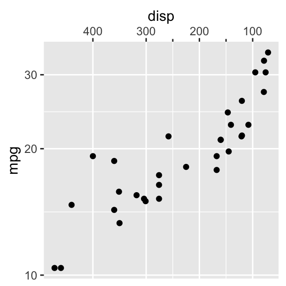

```r
ggplot(mtcars, aes(x= disp,y= mpg)) +
  geom_point() +
  scale_x_reverse(
    breaks = c(100, 200, 300, 400),
    minor_breaks = c(150, 250),
    position = "top",
    guide = guide_axis(minor.ticks = TRUE)
  ) +
  scale_y_log10()
```

What is wrong?

# 8 Guides

For other guides, such as legends for sizes, shapes, and color mappings, most of the control of the guides is instead covered through the `guides()` function. In fact, it may be better to think of the `guides()` function as a function that controls legends.

For example, the following plot maps colour to the number of cylinders. The expression `factor(cyl)` treats the cylinder counts as categories, so ggplot2 adds a colour legend:

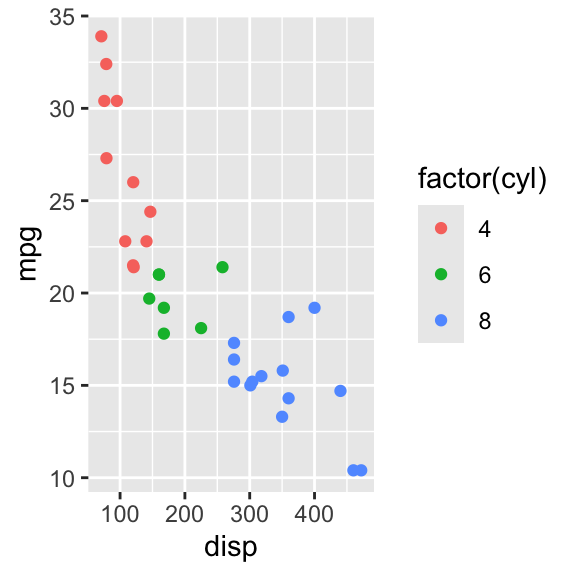

```r
ggplot(mtcars, aes(x = disp,y = mpg, colour = factor(cyl))) +
  geom_point()
```

To remove a legend that is redundant[^1], set its guide to `"none"`. Here, `guides(colour = "none")` removes the colour legend while keeping the point colours and both axes:

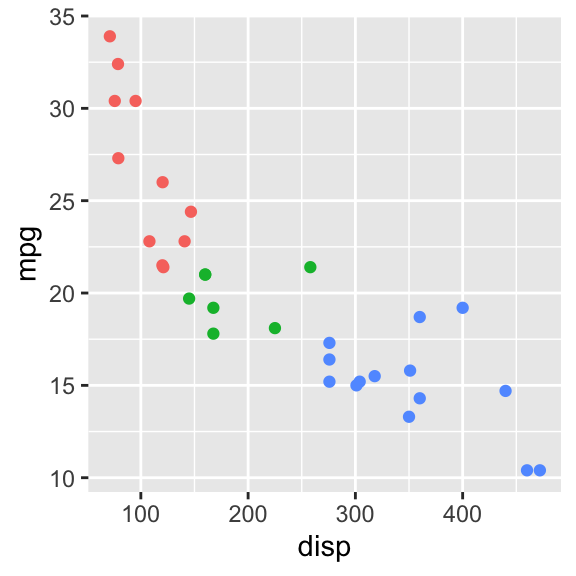

```r
ggplot(mtcars, aes(disp, mpg, colour = factor(cyl))) +
  geom_point() +
  guides(colour = "none")
```

If you want to read more about modifying guides (legends), check out this page: https://ggplot2.tidyverse.org/reference/guides.html.

# 9 Labeling Guides

Labeling your guides is very important, and it’s probably the aspect of the course we nitpick the most, aside from maybe improper figure sizing and non-descriptive figure captions.

It’s fortunately very easy to do in ggplot2. Just use the `labs()` function. The basic recipe is `labs(<guide> = <name>)`. So, to label the guides in the `mtcars` example, for instance, you would just do:

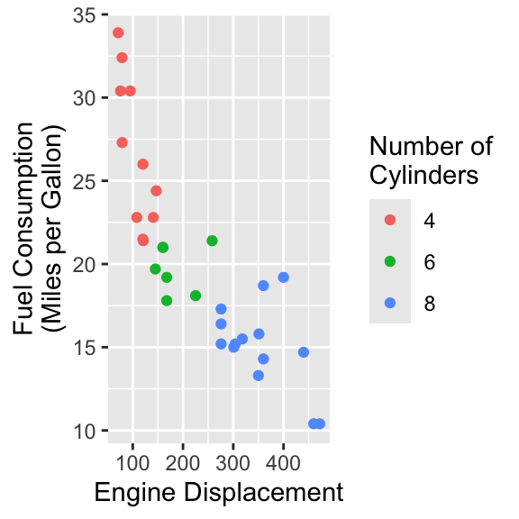

```r
ggplot(mtcars, aes(disp, mpg, color = factor(cyl))) +
  geom_point() +
  labs(
     x = "Engine Displacement",
     y = "Fuel Consumption\n(Miles per Gallon)",
     color = "Number of\nCylinders"
  )
```

Notice the use of the special character `"\n"` in these labels. As you can see on the plot, they add line breaks inside the titles, which is very useful if you have long titles that don’t fit otherwise or just don’t want to waste space on a long title label for the legend.

Just like with limits, there are shortcuts for the x and y coordinates here too: `xlab()` and `ylab()`.

# 10 Data and Mappings in Individual Layers

So far, we’ve usually supplied the data and aesthetic mappings in the `ggplot()` call, where they become defaults for all layers. Sometimes we want a layer to use different data or different mappings, for instance when adding a summary to a plot of individual observations. Data and mappings are inherited separately.

### 10.0.1 Supplying Data and Mappings in a Layer

You can define the mappings directly in `geom_point()`, which also has a `mapping` argument. The following code gives the same scatter plot as our first example, but the mappings belong only to the point layer:

```r
ggplot(data= mtcars) +
  geom_point(aes(x=disp,y= mpg))
```

Layer functions also have their own `data` argument, so we can supply both the data and the mappings in the layer itself:

```r
ggplot() +
  geom_point(aes(disp, mpg), data = mtcars)
```

Again, we get the same plot. But another layer would not inherit the data or mappings from this point layer: layers inherit defaults from `ggplot()`, not from one another.

### 10.0.2 Adding a Layer with Different Data

Let’s add a point showing the overall mean engine displacement and mean fuel economy. First, we create a dataset with one row:

```r
car_means <- data.frame(
  disp = mean(mtcars$disp),
  mpg = mean(mtcars$mpg)
)
```

We can now give the second point layer its own dataset:

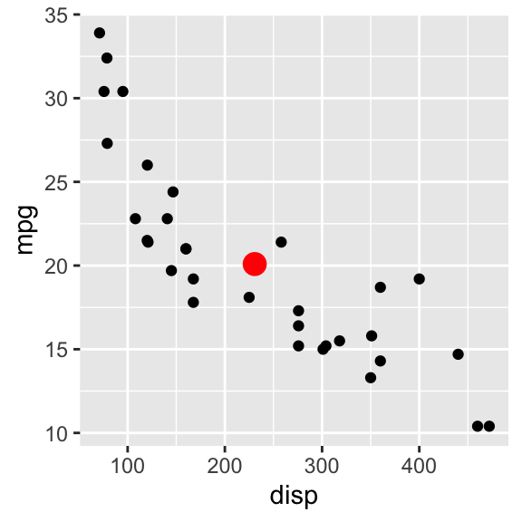

```r
ggplot(data = mtcars, aes(x= disp,y= mpg)) +
  geom_point() +
  geom_point(data = car_means, colour = "red", size = 4)
```

The first layer uses `mtcars`, while the second uses `car_means`. Both inherit the mappings `aes(disp, mpg)` from `ggplot()`, because both datasets contain those variables. Using a different dataset does not automatically require turning off mapping inheritance.

### 10.0.3 Turning Off Mapping Inheritance

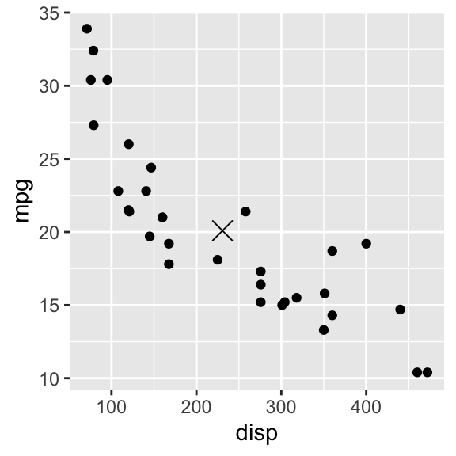

```r
ggplot(mtcars,aes(x=disp,y= mpg)) +
  geom_point() +
  geom_point(
    data = car_means,
    shape = 4,
    size = 4
  )
```

See the [layer documentation](https://ggplot2.tidyverse.org/reference/geom_point.html) for more details.

# 11 Changing the Appearance of Your Plots

The appearance of ggplots can be varied in a great many ways and the interface for doing so is the `theme()` function. The number of options is staggering, but thankfully you will rarely need to mess with them directly, except for a couple of options that will often come in handy.

In particular, it’s very useful to know how to re-position legends, which you do using the `legend.position` argument in the call. By default, legends will always be placed on the right of the plot. But sometimes you need that space for the canvas, perhaps just to alleviate issues with overlap. It’s very easy to do so:

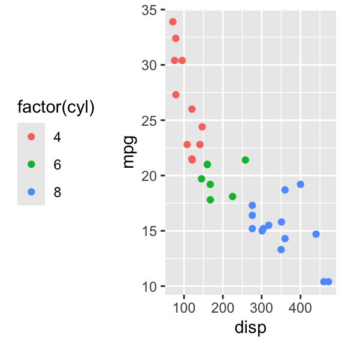

```r
ggplot(mtcars, aes(disp, mpg, color = factor(cyl))) +
  geom_point() +
  theme(legend.position = "left") # top, left, right, bottom
```

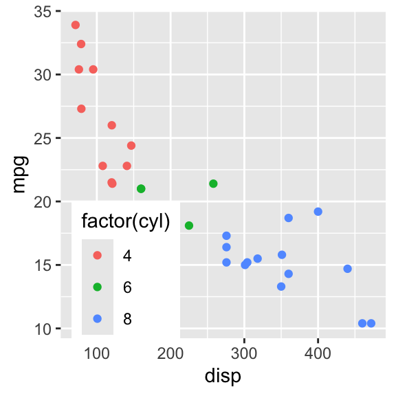

```r
ggplot(mtcars, aes(disp, mpg, color = factor(cyl))) +
  geom_point() +
  theme(legend.position = c(0.2, 0.2))
```

The full list of options for the `theme()` function is available at https://ggplot2.tidyverse.org/reference/theme.html.

# 12 Themes

If you want to modify the appearance of all of your plots, the simplest way of doing so is to switch theme for your plots. There are many built-in themes in ggplot2[^2]. The default theme, which you’ve seen exemplified several times by now, is `theme_grey()` and for most of the plots in this course, we will stick to that.

Changing the theme for your plots can be done on a plot-by-plot basis, by simply adding the theme you want to your plot, like this:

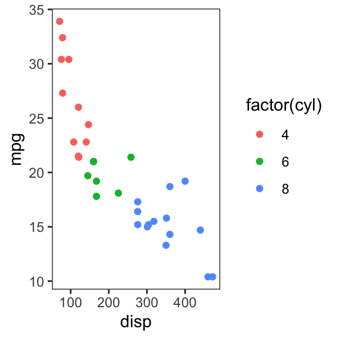

```r
ggplot(mtcars, aes(disp, mpg, color = factor(cyl))) +
  geom_point() +
  theme_bw() + theme(panel.grid = element_blank())
```

But it’s also possible to change the default theme for your entire session by calling `theme_set()` somewhere in your R source (or R Markdown) document, like this:

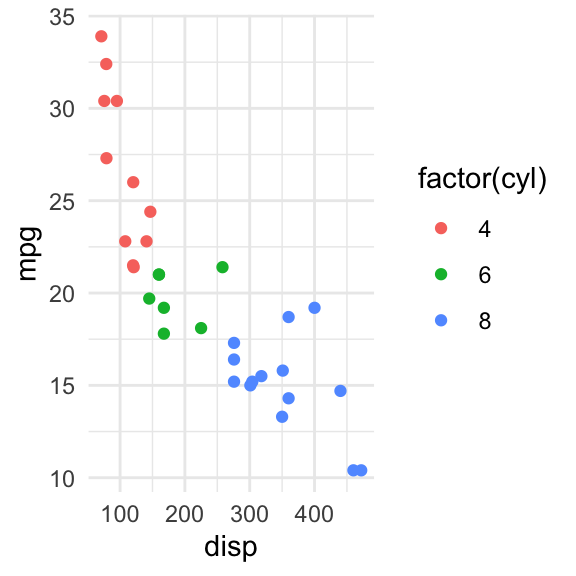

```r
theme_set(theme_minimal())

ggplot(mtcars, aes(disp, mpg, color = factor(cyl))) +
  geom_point()
```

You are free to choose theme for yourself, but I highly recommend that you try to stick to one and the same theme for any given report to create a uniform design for your reports.

There are other packages that provide additional themes for ggplot2 too. If you are interested, we recommend you check out ggthemes and cowplot.

# 13 Source Code

The source code for this document is available at https://github.com/stat-lu/dataviz/blob/main/worked-examples/first-steps-with-ggplot2.Rmd.

[^1]: You’ll find out more about redundant ink later on in the course.
[^2]: For a full list, see https://ggplot2.tidyverse.org/reference/ggtheme.html.